# House Selling Prices

Nov. 18th, 2019

```r
library(tidyverse)
library(ggplot2)
library(readr)
library(data.table)
library(DT)
library(pander)
library(scales)
library(cowplot)
library(shiny)
library(usethis)
library(gganimate)
library(gapminder)
```

## Data

The original data can be found [here](https://www.kaggle.com/c/house-prices-advanced-regression-techniques/data).

The code below reads in the dataset, selects the variable names we will use for our model, and displays the set in an interactive data table.

```r
data <- read_csv("train.csv")
house_data <- select(data, c(SalePrice, GrLivArea, YearBuilt, OverallQual)) %>% na.omit()
datatable(house_data)
```

|  | SalePrice | GrLivArea | YearBuilt | OverallQual |
| --- | --- | --- | --- | --- |
| 1 | 208500 | 1710 | 2003 | 7 |
| 2 | 181500 | 1262 | 1976 | 6 |
| 3 | 223500 | 1786 | 2001 | 7 |
| 4 | 140000 | 1717 | 1915 | 7 |
| 5 | 250000 | 2198 | 2000 | 8 |
| 6 | 143000 | 1362 | 1993 | 5 |
| 7 | 307000 | 1694 | 2004 | 8 |
| 8 | 200000 | 2090 | 1973 | 7 |
| 9 | 129900 | 1774 | 1931 | 7 |
| 10 | 118000 | 1077 | 1939 | 5 |

[output cut: 1450 more lines]

#### Description of Dataset

The dataset contains 1, 460 observations of 4 continuous variables: *SalePrice* - Selling price of the home (in dollars), *GrLivArea* - Square feet of living area, *YearBuilt* - year home was built in, *OverallQual* = rating of quality (ranging from 1 to 10).

For this analysis, the response variable will be the *SalePrice* and the independent variables will be the remaining three. Even though there are only 10 possible values or categories for *OverallQual*, it will be used as a continuous variable in this analysis.

Here is a summary of the data:

```r
pander(summary(house_data))
```

| SalePrice | GrLivArea | YearBuilt | OverallQual |
| --- | --- | --- | --- |
| Min. : 34900 | Min. : 334 | Min. :1872 | Min. : 1.000 |
| 1st Qu.:129975 | 1st Qu.:1130 | 1st Qu.:1954 | 1st Qu.: 5.000 |
| Median :163000 | Median :1464 | Median :1973 | Median : 6.000 |
| Mean :180921 | Mean :1515 | Mean :1971 | Mean : 6.099 |
| 3rd Qu.:214000 | 3rd Qu.:1777 | 3rd Qu.:2000 | 3rd Qu.: 7.000 |
| Max. :755000 | Max. :5642 | Max. :2010 | Max. :10.000 |

## Exploratory Data Analysis

We will look at the distribution of the price as well as the price broken up by each of the independent variables as an initial to examine the data.

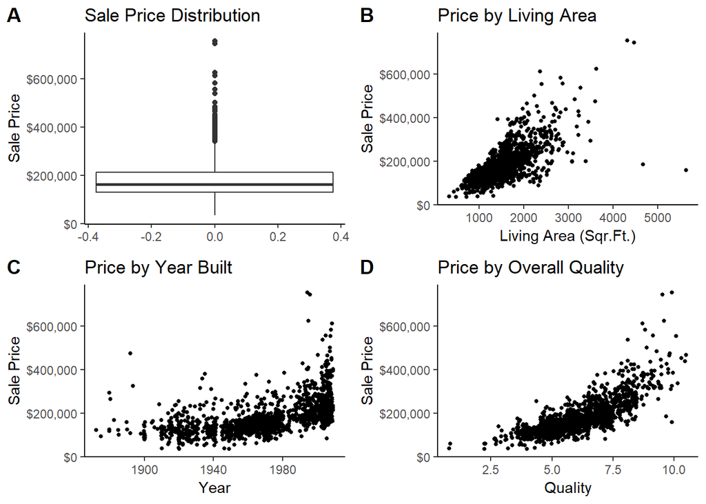

```r
price <- ggplot(house_data, aes(y = SalePrice)) +
  geom_boxplot() +
  theme_classic() +
  labs(title = "Sale Price Distribution", y = "Sale Price") +
  scale_y_continuous(labels = dollar_format())

liv <- ggplot(house_data, aes(GrLivArea, SalePrice)) +
  geom_jitter(width = .5, size = 1) +
  labs(title = "Price by Living Area",
       y = "Sale Price",
       x = "Living Area (Sqr.Ft.)") +
  scale_y_continuous(labels = dollar_format()) +
  theme_classic()

year <- ggplot(house_data, aes(YearBuilt, SalePrice)) +
  geom_jitter(width = .5, size = 1) +
  labs(title = "Price by Year Built",
       y = "Sale Price",
       x = "Year") +
  scale_y_continuous(labels = dollar_format()) +
  theme_classic()

qual <- ggplot(house_data, aes(OverallQual, SalePrice)) +
  geom_jitter(width = .5, size = 1) +
  labs(title = "Price by Overall Quality",
       y = "Sale Price",
       x = "Quality") +
  scale_y_continuous(labels = dollar_format()) +
  theme_classic()

plot_grid(price, liv, year, qual, labels = "AUTO")
```

## Finding the Predictive Model

#### Establishing Null Hypothesis

The null hypothesis is that the variation in the price, cannot be explained by anything other than randomization. In other words, the variation in living area square footage, year built, or quality of the house cannot explain the variation in price.

Let’s have a closer look at the scattergram for relationships between SalePrice and the independent variables:

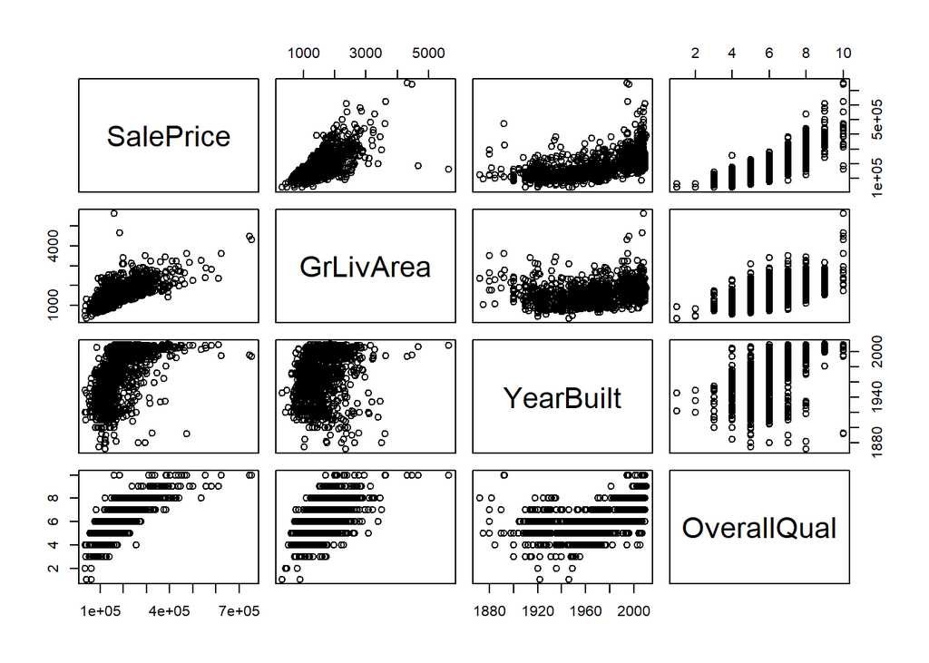

```r
plot(house_data)
```

```r
pander(cor(house_data))
```

|  | SalePrice | GrLivArea | YearBuilt | OverallQual |
| --- | --- | --- | --- | --- |
| **SalePrice** | 1 | 0.7086 | 0.5229 | 0.791 |
| **GrLivArea** | 0.7086 | 1 | 0.199 | 0.593 |
| **YearBuilt** | 0.5229 | 0.199 | 1 | 0.5723 |
| **OverallQual** | 0.791 | 0.593 | 0.5723 | 1 |

The correlation is very evident between price and all three other variables which confirms we are on the right path. From the correlation matrix we see the Overall Quality is the most correlated variable.

#### Attempting a First Model

In this first entry model, all the independent variables will be included at once.

```r
first_model <- lm(data = house_data, SalePrice ~ GrLivArea + YearBuilt + OverallQual)
pander(summary(first_model))
```

|  | Estimate | Std. Error | t value | Pr(>\|t\|) |
| --- | --- | --- | --- | --- |
| **(Intercept)** | -1052669 | 83762 | -12.57 | 1.827e-34 |
| **GrLivArea** | 62.09 | 2.581 | 24.06 | 5.836e-108 |
| **YearBuilt** | 500.1 | 44.09 | 11.34 | 1.221e-28 |
| **OverallQual** | 25196 | 1172 | 21.5 | 2.75e-89 |

Fitting linear model: SalePrice ~ GrLivArea + YearBuilt + OverallQual

| Observations | Residual Std. Error | $R^2$ | Adjusted $R^2$ |
| --- | --- | --- | --- |
| 1460 | 40753 | 0.7374 | 0.7368 |

Great Living Area Square Footage, Year Built, and Overall Quality of a house explain **74%** of the price, as evident from the adjusted $R^2$ value. Furthermore, when we look at the p-values for each independent variable, we see that they are significant, suggesting they help explain the variation in house price. Thus, we reject the null hypothesis.

Next, a model for house price will be built using different methods to see if a higher $R^2$ value can be achieved (a better model).

#### Attempting Another Model

```r
## Checking if interaction with quality changes something.

pairs(cbind(R=first_model$res, fit=first_model$fit, house_data), col=factor(house_data$OverallQual))

##I'll add the OverallQual:GrLivArea interaction

second_model <- lm(data = house_data, SalePrice ~ GrLivArea + YearBuilt + OverallQual + GrLivArea:OverallQual)
pander(summary(second_model)) #Adjusted R-squared 0.7566 but GrLivArea ALMOST insignificant

##Let's drop the YearBuilt and check
third_model <- lm(data = house_data, SalePrice ~ GrLivArea + OverallQual + YearBuilt:OverallQual + GrLivArea:OverallQual)
pander(summary(third_model)) #0.7622

##Let's add YearBUilt to previous model
fourth_model <- lm(data = house_data, SalePrice ~ GrLivArea + YearBuilt + OverallQual + YearBuilt:OverallQual + GrLivArea:OverallQual)
pander(summary(fourth_model)) #0.7642 but GrLivArea insignificant

fith_model <- lm(data = house_data, SalePrice ~  YearBuilt + OverallQual + YearBuilt:OverallQual + GrLivArea:OverallQual)
pander(summary(fith_model)) #0.7643
```

[output not shown]

When you check at the code above you can see that I have attempted a few things to get a better model but most of them don’t vary that much, and because of this I’ll use the simplest one for coding purposes and to avoid overfitting.

#### Plotting the Model

Mathematically, we can write our model as follows:

$$\text{House Price} = -1,052,669 + 62.09 \text{ Living Area} + 500.1\text{ Year} + 25, 196 \text{ Quality} + \epsilon_i$$

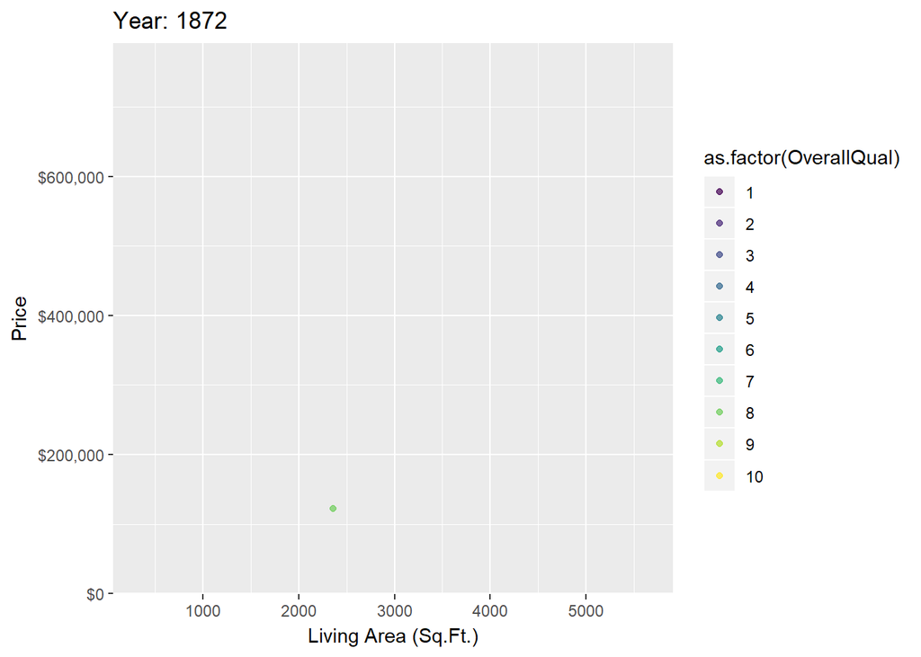

```r
ggplot(house_data,
            aes(x = GrLivArea, y=SalePrice, colour = as.factor(OverallQual))) +
  geom_point(show.legend = TRUE, alpha = 0.7) +
  #geom_smooth(method = 'lm', se = FALSE)
  scale_color_viridis_d() +
  scale_size(range = c(2, 12)) +
  labs(x = "Living Area (Sq.Ft.)", y = "Price") +
  scale_y_continuous(labels = dollar_format()) +
  transition_time(YearBuilt) +
  labs(title = "Year: {frame_time}")
```

#### Checking Assumptions

First, we will check that the data meets the normality assumption:

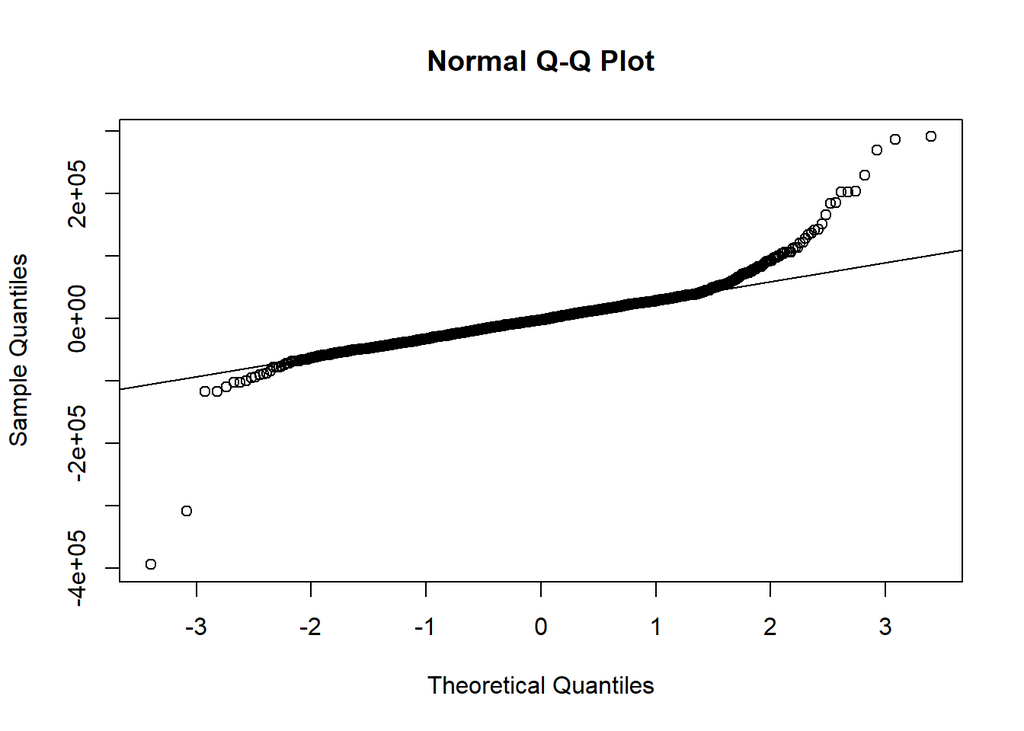

```r
qqnorm(residuals(first_model))
qqline(residuals(first_model))
```

The residuals appear to be normally distributed. They tail off at the upper and lower ends, but a majority fit the line well. The few that tail off could be due to the outliers that were left in the dataset for analysis.

Finally, to check the fit of the model, we will examine the model residuals:

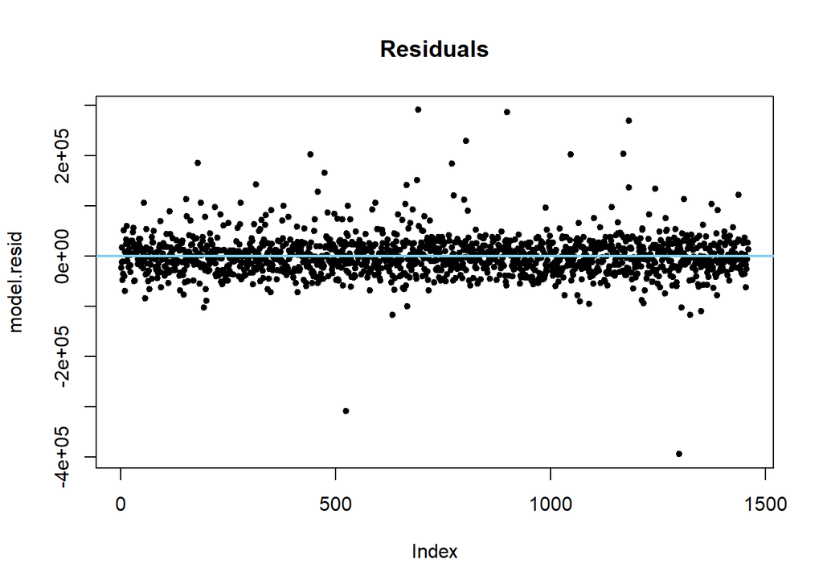

```r
model.resid <- first_model$residuals
plot(model.resid, main="Residuals",pch=20)
abline(0,0, lwd=2, col="skyblue")
```

The resididuals show the difference between the actual and fitted values of the model. They are spread out across the dynamic range and distributed equally about the 0, indicating the model is a good fit!